# Question

Consider the $L$-system (and angle) defined below:

- Start: `A++A++A++A`
- Rules:  
  `A > B-CAC-B`  
  `B > AB-BA`  
  `C > CC`
- Number of recursions (number of iterations):
  - 5
- Angle
  - 135°

When we use the resulting string (and angle) to drive turtle graphics, using https://draemm.li/various/fractals/l-systems/, what image is produced?

You can also use [this L-system string generator](https://chadworley.github.io/Lsys_string_gen.html) along with [Turbo Turtle](https://scratch.mit.edu/projects/1225522722/editor/) to generate the pattern.

(You will need to adjust other parameters to get image rotated, centered, and scaled.)

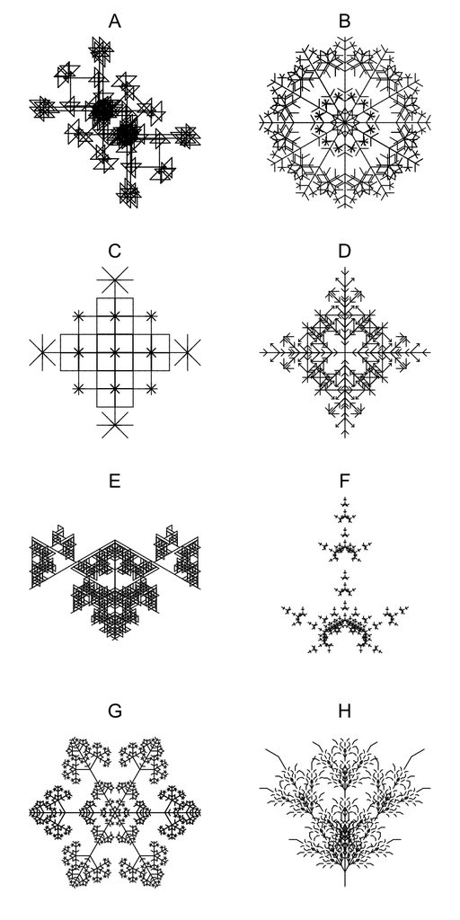

## Answerlist

- A
- B
- C
- D
- E
- F
- G
- H

# Solution

The correct pattern is pattern A.

1. Use the link: https://draemm.li/various/fractals/l-systems/
2. Copy in the starting string, replacement rules, number of recursions, and angle.
3. Adjust the center and scale to clearly see the pattern. You might also need to rotate the pattern.
4. Select the correct pattern.

In case you’re interested in the parameters of the other patterns shown:

## Pattern A

- Start: `A++A++A++A`
- Rules:  
  `A > B-CAC-B`  
  `B > AB-BA`  
  `C > CC`
- Number of recursions (number of iterations):
  - 5
- Angle
  - 135

## Pattern B

- Start: `A+A++++++A+A`
- Rules:  
  `A > [---B][-B][+B][+++B]`  
  `B > BD[++DA][--DA]B`  
  `D > DD`
- Number of recursions (number of iterations):
  - 4
- Angle
  - 30

## Pattern C

- Start: `A`
- Rules:  
  `A > [----AAB][--AAB][++AAB]AAB`  
  `B > [-C][+C][--C][++C][---C][+++C]`  
  `C > CAB`
- Number of recursions (number of iterations):
  - 3
- Angle
  - 45

## Pattern D

- Start: `[A]--[A]--[A]--[A]`
- Rules:  
  `A > C[+CB][CCA][-CB]`  
  `B > CCC[+++A][---A]`  
  `C > CA`
- Number of recursions (number of iterations):
  - 4
- Angle
  - 45

## Pattern E

- Start: `[+A][-B]`
- Rules:  
  `A > [-CA-CB]A`  
  `B > [+CB+CA]B`  
  `C > CC`
- Number of recursions (number of iterations):
  - 6
- Angle
  - 120

## Pattern F

- Start: `A`
- Rules:  
  `A > X[-A][+A]AA`  
  `X > XX`
- Number of recursions (number of iterations):
  - 5
- Angle
  - 60

## Pattern G

- Start: `A------A`
- Rules:  
  `A > [---B][-B][+B][+++B]`  
  `B > BD[++DA][--DA]B`  
  `D > DD`
- Number of recursions (number of iterations):
  - 5
- Angle
  - 30

## Pattern H

- Start: `X`
- Rules:  
  `F > FF`  
  `X > F[+XXF+F][-XXF-F]FXX`
- Number of recursions (number of iterations):
  - 4
- Angle
  - 30

# Meta-information

extype: schoice exsolution: 10000000 exname: lsys_pattern